# Citibike Case Analysis-LiuJiaxing- LSGI535 Project

### Background

**Objective:** LSGI535 Project analysis Citi Bike data.

**Content:**

```
  To meet the requirements of LSGI535- Project, I have done following works, some of functions are based on open-source codes.
  1. Top stations with the most starts (showing # of starts)
2. Trip duration by user type
3. Most popular trips based on start station and stop station)
4. Rider performance by Gender and Age based on avg trip distance (station to station),
   median speed (trip duration / distance traveled)
5. Busiest bike and how many minutes was it in use?
6. A model that can predict how long a trip will take given a starting point and destination.
```

First, load in the data set.

The dataset is massive. Additionally, the data is very dirty. Different files have different column names, need to account for this.

```python
###################### Load Libraries and Data ######################
import numpy as np
import matplotlib.pyplot as plt
import pandas as pd
from pandas import *
import seaborn as sns
from matplotlib import rcParams
import datetime as dt
```

### Part 1: Top 5 Stations

```python
#Set working directory to correct folder, or add path
#Minimize work to load data. Can be done in other ways as well. There may be a more effecient way to do this. Haven't explored this too deeply.

df = concat([read_csv(f, header=None,low_memory=False) for f in files], keys=files) #header = None because some files don't have a header
df.describe()
df.describe(include = all)
df.dtypes

df2 = pd.read_csv('jan.csv')
df.columns = df2.columns
del[df2]
df = df[df[1] != 'starttime']
df = df[df[1] != 'Start Time']
#Saved csv
#df.to_csv('citibike=all.csv')
```

```python
#Load aggregated dataset to minimize time needed to run the code
df = read_csv('F:/workspace/JC_combined_data_clean.csv')
#df = df.drop(['Unnamed: 0', 'Unnamed: 1'], axis = 1)
df_copy = df
df.head()
```

|  | Unnamed: 0 | tripduration | starttime | stoptime | start station id | start station name | start station latitude | start station longitude | end station id | end station name | end station latitude | end station longitude | bikeid | usertype | birth year | gender | year | month |
| --- | --- | --- | --- | --- | --- | --- | --- | --- | --- | --- | --- | --- | --- | --- | --- | --- | --- | --- |
| 0 | 0 | 61 | 2015-09-21 14:53:16 | 2015-09-21 14:54:17 | 3185 | City Hall | 40.717732 | -74.043845 | 3185 | City Hall | 40.717732 | -74.043845 | 24722 | Subscriber | 1975.0 | 1 | 2015 | 9 |
| 1 | 2 | 786 | 2015-09-21 14:56:14 | 2015-09-21 15:09:21 | 3183 | Exchange Place | 40.716247 | -74.033459 | 3183 | Exchange Place | 40.716247 | -74.033459 | 24442 | Subscriber | 1962.0 | 1 | 2015 | 9 |
| 2 | 3 | 477 | 2015-09-21 14:58:35 | 2015-09-21 15:06:32 | 3203 | Hamilton Park | 40.727596 | -74.044247 | 3203 | Hamilton Park | 40.727596 | -74.044247 | 24678 | Subscriber | 1977.0 | 2 | 2015 | 9 |
| 3 | 4 | 451 | 2015-09-21 14:59:55 | 2015-09-21 15:07:27 | 3203 | Hamilton Park | 40.727596 | -74.044247 | 3186 | Grove St PATH | 40.719586 | -74.043117 | 24574 | Subscriber | 1977.0 | 2 | 2015 | 9 |
| 4 | 5 | 401 | 2015-09-21 15:06:03 | 2015-09-21 15:12:44 | 3195 | Sip Ave | 40.730743 | -74.063784 | 3195 | Sip Ave | 40.730743 | -74.063784 | 24520 | Subscriber | 1987.0 | 2 | 2015 | 9 |

```python
#Percentage of missing data.
def missing_data(df):
    total = df.isnull().sum().sort_values(ascending=False)
    percent = (df.isnull().sum()/df.isnull().count()*100).sort_values(ascending=False)
    missing_data = pd.concat([total, percent], axis=1, keys=['Total', 'Percent'])
    return missing_data
missing_data(df)
```

|  | Total | Percent |
| --- | --- | --- |
| usertype | 497 | 0.037589 |
| month | 0 | 0.000000 |
| start station longitude | 0 | 0.000000 |
| tripduration | 0 | 0.000000 |
| starttime | 0 | 0.000000 |
| stoptime | 0 | 0.000000 |
| start station id | 0 | 0.000000 |
| start station name | 0 | 0.000000 |
| start station latitude | 0 | 0.000000 |
| end station id | 0 | 0.000000 |
| year | 0 | 0.000000 |
| end station name | 0 | 0.000000 |
| end station latitude | 0 | 0.000000 |
| end station longitude | 0 | 0.000000 |
| bikeid | 0 | 0.000000 |
| birth year | 0 | 0.000000 |
| gender | 0 | 0.000000 |
| Unnamed: 0 | 0 | 0.000000 |

```python
#Ensure data is formatted correctly to avoid errors in the visuals
df['Start Time'] = to_datetime(df['starttime'])
df['Stop Time'] = to_datetime(df['stoptime'])
df['Start Station Name'] = df['start station name'].astype('category')
df['End Station Name'] = df['end station name'].astype('category')
df['User Type'] = df['usertype'].astype('category')
df['Gender'] = df['gender'].astype('category')
round(df.describe(),2)
```

|  | Unnamed: 0 | tripduration | start station id | start station latitude | start station longitude | end station id | end station latitude | end station longitude | bikeid | birth year | gender | year | month |
| --- | --- | --- | --- | --- | --- | --- | --- | --- | --- | --- | --- | --- | --- |
| count | 1322189.00 | 1322189.00 | 1322189.00 | 1322189.00 | 1322189.00 | 1322189.00 | 1322189.00 | 1322189.00 | 1322189.00 | 1322189.00 | 1322189.00 | 1322189.00 | 1322189.00 |
| mean | 714289.83 | 613.29 | 3253.78 | 40.72 | -74.05 | 3250.20 | 40.72 | -74.05 | 28329.26 | 1980.78 | 1.23 | 2017.72 | 7.00 |
| std | 409120.93 | 16533.13 | 129.92 | 0.01 | 0.01 | 139.62 | 0.01 | 0.01 | 3487.95 | 10.00 | 0.42 | 1.27 | 3.15 |
| min | 0.00 | 61.00 | 3183.00 | 40.69 | -74.10 | 79.00 | 40.68 | -74.10 | 14529.00 | 1904.00 | 1.00 | 2015.00 | 1.00 |
| 25% | 359993.00 | 231.00 | 3191.00 | 40.72 | -74.05 | 3186.00 | 40.72 | -74.05 | 26191.00 | 1976.00 | 1.00 | 2017.00 | 5.00 |
| 50% | 715697.00 | 340.00 | 3203.00 | 40.72 | -74.04 | 3203.00 | 40.72 | -74.04 | 29226.00 | 1983.00 | 1.00 | 2018.00 | 7.00 |
| 75% | 1066026.00 | 558.00 | 3269.00 | 40.73 | -74.04 | 3268.00 | 40.73 | -74.04 | 29580.00 | 1988.00 | 1.00 | 2019.00 | 10.00 |
| max | 1420934.00 | 16329808.00 | 3792.00 | 40.75 | -74.03 | 3792.00 | 40.81 | -73.93 | 42636.00 | 2003.00 | 2.00 | 2020.00 | 12.00 |

```python
#Quasi Confirm Hypothesis in point #3
df_bikenum = pd.DataFrame()
df_bikenum['First Bike'] = df[df['tripduration'] < 60]['start station name']
df_bikenum['Second Bike'] = df[df['tripduration'] < 60]['end station name']
#df_bikenum.head()
```

```python
#Clear up enviornment and drop double count
del(df_bikenum)
df = df.drop(df.index[(df['tripduration'] < 60) &
                          (df['start station latitude'] == df['end station latitude'])])
```

```python
#Data for Top 5 Stations visual
top5 = pd.DataFrame()
top5['Station']=df['start station name'].value_counts().head().index
top5['Number of Starts']=df['start station name'].value_counts().head().values
#top5['Station'] = top5['Station'].cat.remove_unused_categories()
top5['Station'] = top5['Station'].astype('object')
#top5.sort_values(by = 'Number of Starts', ascending = False)
```

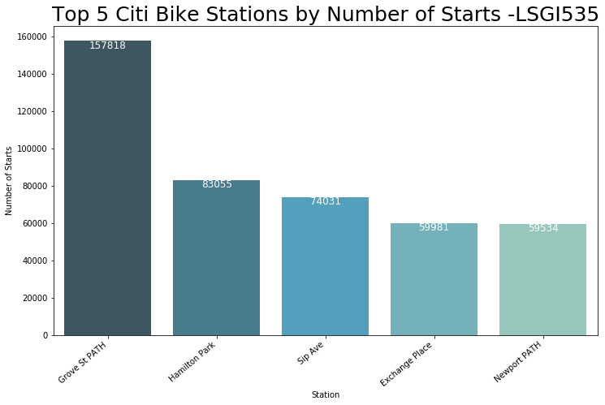

```python
#Plot for Part 1: Top 5 Stations
ax = sns.barplot('Station', 'Number of Starts', data = top5, palette="GnBu_d")
ax.set_title('Top 5 Citi Bike Stations by Number of Starts -LSGI535', fontsize = 25)
rcParams['figure.figsize'] = 12,7
ax.set_xticklabels(ax.get_xticklabels(),rotation=40, ha = 'right')
for index, row in top5.iterrows():
    ax.text(index,row['Number of Starts']-4000,row['Number of Starts'],
            color='white', ha="center", fontsize = 12)
plt.show()
```

### Part 2: Trip Duration by User Type

**According to Citi Bikes' website:** The first 45 minutes of each ride is included for Annual Members, and the first 30 minutes of each ride is included for Day Pass users. If you want to keep a bike out for longer, it’s only an extra $4 for each additional 15 minutes.

**Anomalies**: Any trip which lasts longer than 2 hours (7,200 seconds) probably indicates a stolen bike, an anomaly, or incorrect docking of the bike.

```python
del(top5)
#Drop NA Usertype
df = df.dropna(subset=['User Type'])
```

```python
#Calculate trip duration
TD_user = pd.DataFrame()
TD_user['Avg. Trip Duration'] = round(df.groupby('User Type')['tripduration'].mean(),2)
TD_user = TD_user.reset_index()
TD_user['User Type'] = TD_user['User Type'].astype('object')
```

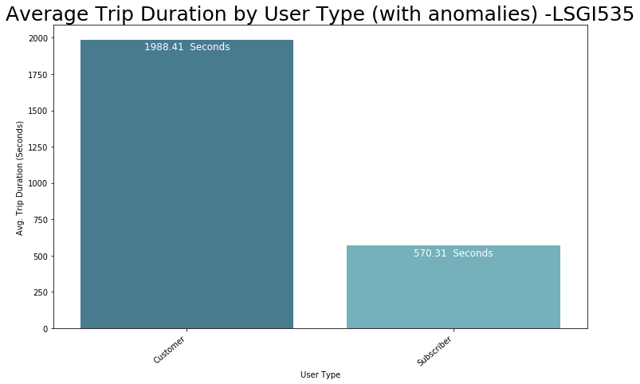

```python
#Average trip Duration per User Type with Anomalies
ax2 = sns.barplot('User Type', 'Avg. Trip Duration', data = TD_user,palette="GnBu_d")
ax2.set_title('Average Trip Duration by User Type (with anomalies) -LSGI535', fontsize = 25)
#rcParams['figure.figsize'] = 12,7
ax2.set_xticklabels(ax2.get_xticklabels(),rotation=40, ha = 'right')
ax2.set_ylabel('Avg. Trip Duration (Seconds)')
for index, row in TD_user.iterrows():
    ax2.text(index,row['Avg. Trip Duration']-70,(str(row['Avg. Trip Duration'])+"  Seconds"),
             color='white', ha="center", fontsize = 12)
plt.show()
```

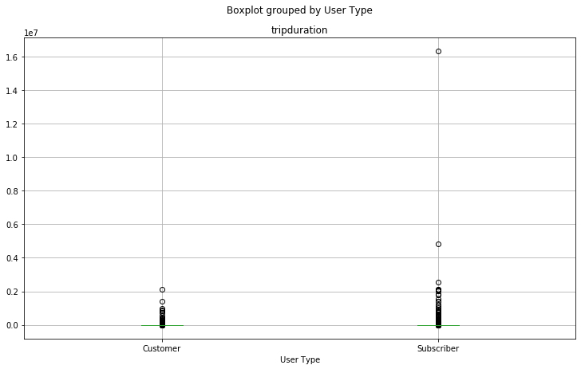

```python
#Boxplots are more informative to visualize breakdown of data
df.boxplot('tripduration', by = 'User Type')
plt.show()
```

```python
#Remove anomalies based on definition above
df = df.drop(df.index[(df['tripduration'] > 7200)])
```

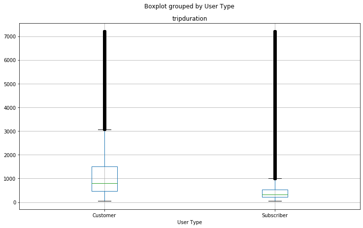

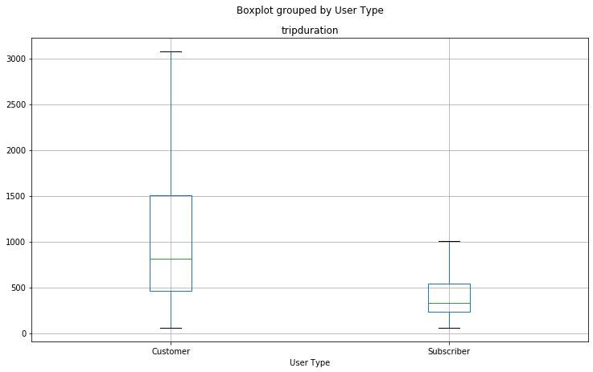

```python
#Boxplots are more informative to visualize breakdown of data
df.boxplot('tripduration', by = 'User Type')
plt.show()
#Boxplot without outliers
df.boxplot('tripduration', by = 'User Type',showfliers=False)
plt.show()
```

```python
#Add Minutes column for Trip Duration
df['Minutes'] = df['tripduration']/60
#For Visual purposes, rounded
df['Minutes'] = round(df['Minutes'])
df['Minutes'] = df['Minutes'].astype(int)
```

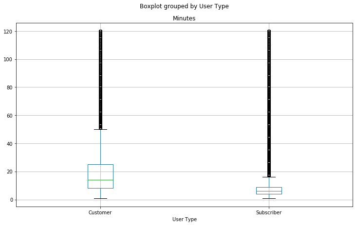

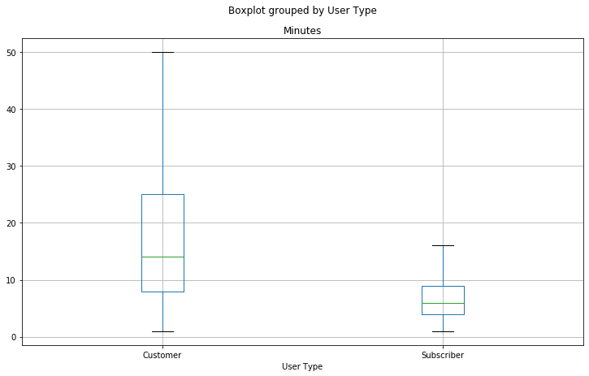

```python
# Could turn of outliers with showfliers = False
df.boxplot('Minutes', by = 'User Type')
plt.show()
df.boxplot('Minutes', by = 'User Type', showfliers = False)
plt.show()
```

```python
TD_user2 = pd.DataFrame()
TD_user2['Avg. Trip Duration'] = round(df.groupby('User Type')['Minutes'].mean(),1)
TD_user2 = TD_user2.reset_index()
TD_user2['User Type'] = TD_user2['User Type'].astype('object')
```

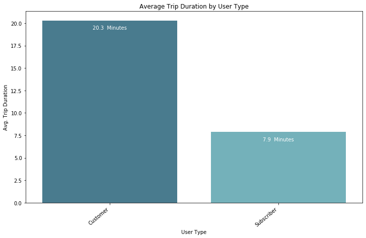

```python
#Average Trip Duration Based on Minutes
ax3 = sns.barplot('User Type', 'Avg. Trip Duration', data = TD_user2,palette="GnBu_d")
ax3.set_title('Average Trip Duration by User Type')
#rcParams['figure.figsize'] = 12,10
ax3.set_xticklabels(ax3.get_xticklabels(),rotation=40, ha = 'right')
for index, row in TD_user2.iterrows():
    ax3.text(row.name,row['Avg. Trip Duration']-1,(str(row['Avg. Trip Duration'])+"  Minutes"),
             color='white', ha="center", fontsize = 10)
plt.show()
```

```python
del(TD_user2)
#Undo rounding for modelling purposes
df['Minutes'] = df['tripduration']/60
```

### Part 3: Most Popular Trip

```python
#Identify the 10 most popular trips
trips_df = pd.DataFrame()
trips_df = df.groupby(['start station name','end station name']).size().reset_index(name = 'Number of Trips')
trips_df = trips_df.sort_values('Number of Trips', ascending = False)
trips_df["start station name"] = trips_df["start station name"].astype(str)
trips_df["end station name"] = trips_df["end station name"].astype(str)
trips_df["Trip"] = trips_df["start station name"] + " to " + trips_df["end station name"]
trips_df = trips_df[:10]
trips_df = trips_df.drop(['start station name', "end station name"], axis = 1)
trips_df = trips_df.reset_index()
#trips_df.head()
```

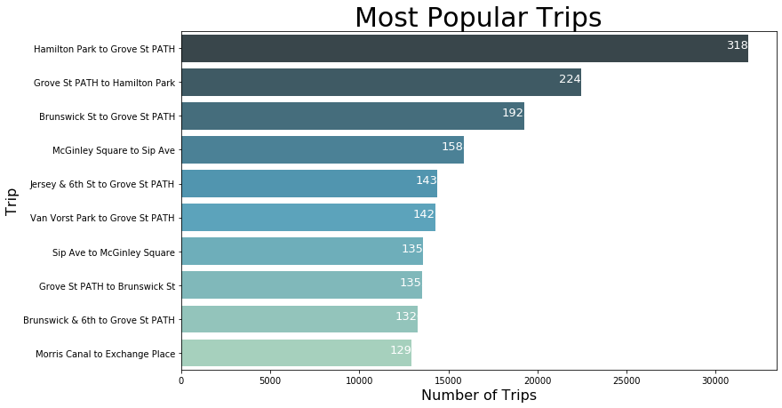

```python
ax4 = sns.barplot('Number of Trips','Trip', data = trips_df,palette="GnBu_d")
ax4.set_title('Most Popular Trips', fontsize = 30)
ax4.set_ylabel("Trip",fontsize=16)
ax4.set_xlabel("Number of Trips",fontsize=16)
for index, row in trips_df.iterrows():
    ax4.text(row['Number of Trips']-220,index,row['Number of Trips'],
             color='white', ha="center",fontsize = 13)
plt.show()
```

### Part 4: Rider Performance by Gender and Age

```python
del(trips_df)
#Drop the tail end of birth years 2 standard deviations below the mean
#df['Birth Year'].mean()-(2*df['Birth Year'].std())
df = df.drop(df.index[(df['birth year'] < 1956)])
```

```python
#Combine coordinates to calculate distance based on Vincenty
df['Start Coordinates'] = list(zip(df['start station latitude'], df['start station longitude']))
df['End Coordinates'] = list(zip(df['end station latitude'], df['end station longitude']))
```

```python
dist = []
for i in range(len(df)):
    dist.append(geopy.distance.vincenty(df.iloc[i]['Start Coordinates'],df.iloc[i]['End Coordinates']).miles)
    if (i%1000000==0):
        print(i)
```

```python
#Reset Index to avoid issues in future calculations
df = df.reset_index()
df = df.drop('index',axis =1)
```

```python
df['Distance'] = dist
```

```python
del(dist)
df['Birth Year'] = df.groupby(['Gender','Start Station ID'])['Birth Year'].transform(lambda x: x.fillna(x.median()))
```

```python
df = df.dropna(subset=['Birth Year'])
```

```python
#Calculate age and drop circular/roundtrips
df['Age'] = 2018 - df['Birth Year']
df['Age'] = df['Age'].astype(int)
```

```python
df = df.drop(df.index[(df['Distance'] == 0)])
```

```python
#1
#df[df['Trip Duration']<60]
#2.
df['Distance'] = df.groupby(['Gender','Start Station ID'])['Distance'].transform(lambda x: x.fillna(x.median()))
```

```python
df['min_mile'] = round(df['Minutes']/df['Distance'], 2)
df['mile_hour'] = round(df['Distance']/(df['Minutes']/60),2)
```

```python
round(df.describe(),2)
```

[output not shown]

```python
df = df[df['Distance'] < 30]
```

```python
#3.1-Done in two steps to ensure data integrity, could've used an or statement as well.
df = df[df['mile_hour']<20]
#3.2
df = df[df['mile_hour']> (df['mile_hour'].mean()-(2*df['mile_hour'].std()))]
```

```python
#Dropping unknown
df1 = df.drop(df.index[(df['Gender'] == 0)])
```

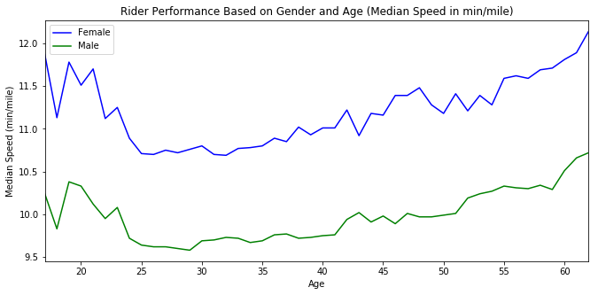

```python
#Rider performance by age and Gender in Min/Mile
fig, ax5 = plt.subplots(figsize=(11,5))
df1.groupby(['Age','Gender']).median()['min_mile'].unstack().plot(ax=ax5, color ="bg")
ax5.legend(['Female','Male'])
plt.ylabel('Median Speed (min/mile)')
plt.title('Rider Performance Based on Gender and Age (Median Speed in min/mile)')
plt.show()
```

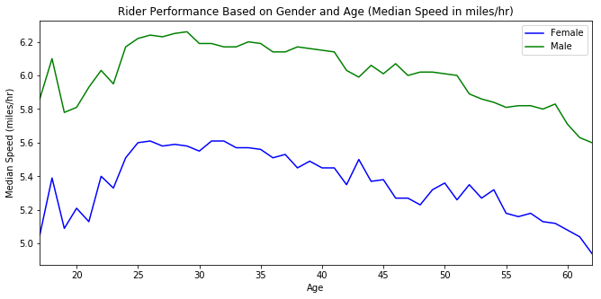

```python
#Rider performance by age and Gender in Miles/hr
del([fig,ax5])
fig1, ax6 = plt.subplots(figsize=(11,5))
df1.groupby(['Age','Gender']).median()['mile_hour'].unstack().plot(ax=ax6,color ="bg")
ax6.legend(['Female', 'Male'])
plt.ylabel('Median Speed (miles/hr)')
plt.title('Rider Performance Based on Gender and Age (Median Speed in miles/hr)')
plt.show()
```

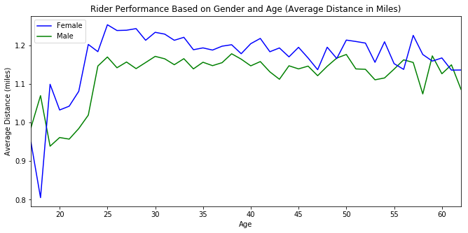

```python
#Rider performance by age and Gender in Averge Distance
del([fig1,ax6])
fig2, ax7 = plt.subplots(figsize=(11,5))
df1.groupby(['Age','Gender']).mean()['Distance'].unstack().plot(ax=ax7,color ="bg")
ax7.legend(['Female', 'Male'])
plt.ylabel('Average Distance (miles)')
plt.title('Rider Performance Based on Gender and Age (Average Distance in Miles)')
plt.show()
```

### Part 5: Busiest Bike by Times and Minutes Used

```python
#Bike usage based on number of times used
bike_use_df = pd.DataFrame()
bike_use_df = df.groupby(['bikeid']).size().reset_index(name = 'Number of Times Used')
bike_use_df = bike_use_df.sort_values('Number of Times Used', ascending = False)
bike_use_df = bike_use_df[:10]
bike_use_df['bikeid'] = bike_use_df['bikeid'].astype(str)
bike_use_df['bikeid'] = ('Bike ' + bike_use_df['bikeid'])
bike_use_df = bike_use_df.reset_index()
#bike_use_df.head()
```

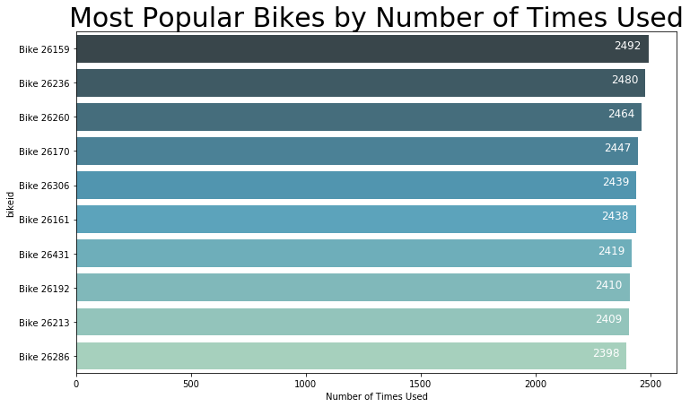

```python
#Visual of most used bike based on Number of Trips
ax8 = sns.barplot('Number of Times Used', 'bikeid',data = bike_use_df, palette="GnBu_d")
ax8.set_title('Most Popular Bikes by Number of Times Used', fontsize = 30)
for index, row in bike_use_df.iterrows():
    ax8.text(row['Number of Times Used']-90,index,row['Number of Times Used'], color='white', ha="center", fontsize =12)
plt.show()
```

```python
#Bike usage based on minutes used
bike_min_df = pd.DataFrame()
bike_min_df['Minutes Used'] = df.groupby('bikeid')['Minutes'].sum()
bike_min_df = bike_min_df.reset_index()
bike_min_df = bike_min_df.sort_values('Minutes Used', ascending = False)
bike_min_df['bikeid'] = bike_min_df['bikeid'].astype(str)
bike_min_df['bikeid'] = ('Bike ' + bike_min_df['bikeid'])
bike_min_df = bike_min_df[:10]
bike_min_df = bike_min_df.reset_index()
#bike_min_df.head()
```

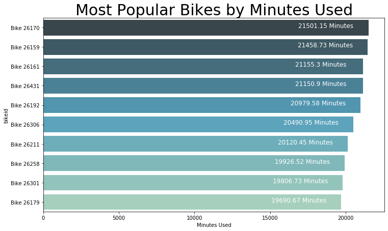

```python
#Visual of most used bike based on number of minutes used
ax9 = sns.barplot('Minutes Used', 'bikeid',data = bike_min_df, palette="GnBu_d")
ax9.set_title('Most Popular Bikes by Minutes Used', fontsize=30)
rcParams['figure.figsize'] = 11,6
for index, row in bike_min_df.iterrows():
    ax9.text(row['Minutes Used']-2800,index,str(round(row['Minutes Used'],2))+' Minutes',
             color='white', ha="center", fontsize =12)
plt.show()
```

### Part 6.1: Predictive Model - Baseline Model

Build a model that can predict how long a trip will take given a starting point and destination.

- Work on a *random* subsample while we build and evaluate models.
  - Get a baseline.
  - Drop irrelevant columns

Basic cleaning of data

- Start Time: Requires reformatting. Will do this after baseline model
  - Dumify categorical variables
  - Scale Age
  - Don't scale distance, since it does not just represent distance, but is also indicative of the trip the rider is making (start and station)

Anomalies in Trip Duration

```python
round(df.describe(),2)
```

|  | Unnamed: 0 | tripduration | start station id | start station latitude | start station longitude | end station id | end station latitude | end station longitude | bikeid | birth year | gender | year | month | Minutes |
| --- | --- | --- | --- | --- | --- | --- | --- | --- | --- | --- | --- | --- | --- | --- |
| count | 1297050.00 | 1297050.00 | 1297050.00 | 1297050.00 | 1297050.00 | 1297050.00 | 1297050.00 | 1297050.00 | 1297050.00 | 1297050.00 | 1297050.00 | 1297050.00 | 1297050.00 | 1297050.00 |
| mean | 715272.71 | 496.27 | 3253.78 | 40.72 | -74.05 | 3250.14 | 40.72 | -74.05 | 28329.56 | 1981.27 | 1.23 | 2017.73 | 7.00 | 8.27 |
| std | 409023.47 | 517.92 | 129.93 | 0.01 | 0.01 | 139.08 | 0.01 | 0.01 | 3484.79 | 9.31 | 0.42 | 1.27 | 3.15 | 8.63 |
| min | 0.00 | 61.00 | 3183.00 | 40.69 | -74.10 | 79.00 | 40.68 | -74.10 | 14529.00 | 1956.00 | 1.00 | 2015.00 | 1.00 | 1.02 |
| 25% | 361367.25 | 231.00 | 3191.00 | 40.72 | -74.05 | 3186.00 | 40.72 | -74.05 | 26191.00 | 1976.00 | 1.00 | 2017.00 | 5.00 | 3.85 |
| 50% | 717468.50 | 339.00 | 3203.00 | 40.72 | -74.04 | 3203.00 | 40.72 | -74.04 | 29226.00 | 1983.00 | 1.00 | 2018.00 | 7.00 | 5.65 |
| 75% | 1067192.75 | 555.00 | 3269.00 | 40.73 | -74.04 | 3268.00 | 40.73 | -74.04 | 29579.00 | 1988.00 | 1.00 | 2019.00 | 10.00 | 9.25 |
| max | 1420934.00 | 7199.00 | 3792.00 | 40.75 | -74.03 | 3792.00 | 40.81 | -73.93 | 42636.00 | 2003.00 | 2.00 | 2020.00 | 12.00 | 119.98 |

```python
#Cleaning up anomalies
df = df.drop(df.index[(df['tripduration'] > 2700)])
```

```python
#Work with a random sample of the data and inspect it thoroughly to ensure it's representative
df_sample = df.sample(frac = 0.1, random_state = 0)
#round(df_sample.describe(),2)
```

### Build a Baseline Model

```python
#Drop Irrelevant data
def drop_data(df):
    df = df.drop(['tripduration','stoptime','start station id','start station latitude','start station longitude',
                  'end station id', 'end station latitude', 'end station longitude',  'bikeid', 'start station name',
                  'birth year','end station name','Stop Time'], axis = 1)
    return df

df_basemodel = drop_data(df_sample)
```

```python
df_basemodel = df_basemodel.drop('Start Time', axis =1)
```

```python
#Dummify categorical data and avoid dummy variable trap
df_basemodel = pd.get_dummies(df_basemodel, drop_first = True)
#df_basemodel.dtypes
```

```python
df_basemodel.corr().loc[:,'Minutes']
```

```
Minutes                 1.000000
Distance                0.848710
User Type_Subscriber   -0.273082
Gender_1               -0.178851
Gender_2                0.046463
Name: Minutes, dtype: float64
```

```python
#Train Test Split
#Predictor variable
X = df_basemodel.iloc[:,1:]
#Target variable
y = df_basemodel.iloc[:,0]

from sklearn.cross_validation import train_test_split
X_train, X_test, y_train, y_test = train_test_split(X, y, test_size = 0.2, random_state = 0)
```

```python
#Fit Linear Regression and check accuracy using sklearn
from sklearn.linear_model import LinearRegression
regressor = LinearRegression()
regressor.fit(X_train, y_train)
regressor.score(X_test,y_test)
```

```
0.7670642738319764
```

```python
#Using Statsmodel because it has the summary function.
import statsmodels.api as sm
X_train = sm.add_constant(X_train)
X_test = sm.add_constant(X_test)
regressor_OLS = sm.OLS(y_train, X_train).fit()
regressor_OLS.summary()
```

OLS Regression Results

[output not shown]

|  | coef | std err | t | P>\|t\| | [0.025 | 0.975] |
| --- | --- | --- | --- | --- | --- | --- |
| const | 8.4552 | 0.015 | 581.543 | 0.000 | 8.427 | 8.484 |
| Distance | 8.3021 | 0.004 | 1867.643 | 0.000 | 8.293 | 8.311 |
| User Type_Subscriber | -5.6523 | 0.022 | -251.293 | 0.000 | -5.696 | -5.608 |
| Gender_1 | -0.9573 | 0.023 | -41.966 | 0.000 | -1.002 | -0.913 |
| Gender_2 | 0.3342 | 0.023 | 14.231 | 0.000 | 0.288 | 0.380 |

| Omnibus: | 382321.757 | Durbin-Watson: | 2.000 |
| --- | --- | --- | --- |
| Prob(Omnibus): | 0.000 | Jarque-Bera (JB): | 2150008.334 |
| Skew: | 1.450 | Prob(JB): | 0.00 |
| Kurtosis: | 8.937 | Cond. No. | 20.0 |